# Telessaúde PDI — Andamento e primeiras entregas

TeleAPS · TeleSAP · AME+Digital · Bolsa PDI 2026 (TO 212.435) — 30/06/2026, atualizado 06/07

Bragatte, M.A.S

## Onde estamos

**Projeto:** análise de dados de telessaúde do PDI — perfil de unidades, população e desempenho em **TeleAPS**, **TeleSAP** e **AME+Digital**.

- **13 análises** planejadas · **16 ciclos** quinzenais · vigência **11/05–31/12/2026**
- Hoje: encerramento do **C3** (junho) — Mês 2 do cronograma
- Eixo de hoje: **com o que temos, dá para entregar?** — e o que falta para avançar

Setup (C1) concluído · TeleAPS T1 em curso (C2–C3) · bases públicas tratadas

## O que já temos

**Infraestrutura analítica**

- Ambiente reproduzível (Python · R · Quarto · Git)
- Relatórios mensais parametrizados (YAML → DOCX)

**Reuso de infraestrutura interna (DRY)**

- **IBGE** e **CNES** já tratados (pipeline interno)
- Geoprocessamento (geobr) reaproveitado

**Bases POC 2024–2025**

| Iniciativa | Linhas | Registros |
| --- | --- | --- |
| TeleAPS | 60.819 | 36.175 |
| TeleSAP | 51.499 | — |
| AME+Digital | 9.265 | — |

*POC = ensaio; entrega definitiva roda nas bases completas (pendentes).*

## Com o que temos, dá para entregar?

**Sim — 8 das 13 análises já entregam** (nível agregado / POC). *T = TeleAPS · S = TeleSAP · A = AME+Digital — o número é a análise específica.*

| Bloco | Entregam **já** | Dependem de pedido |
| --- | --- | --- |
| **Prontas (8)** | T2 · T3 · S1 · S2 · S4 · S5 · A1 · A2 | — |
| **Parciais (3)** | T1 · S3 · A3 | vínculo · CNES · N |
| **Condicionais (2)** | S6 · A4 | vínculo UP · campos operacionais |

**Legenda:** *vínculo* = tabela registro→unidade · *CNES* = código da unidade (**resolvemos internamente**) · *N* = amostra suficiente · *UP* = unidade prisional.

> Nenhuma análise está **bloqueada**: o que falta muda a **granularidade** (agregado → unidade) e o **status** (POC → definitivo).

## Prova de valor

Puxamos dados públicos (IBGE/CNES) e cruzamos com o REDCap do INOVA

## Quem o TeleAPS alcança

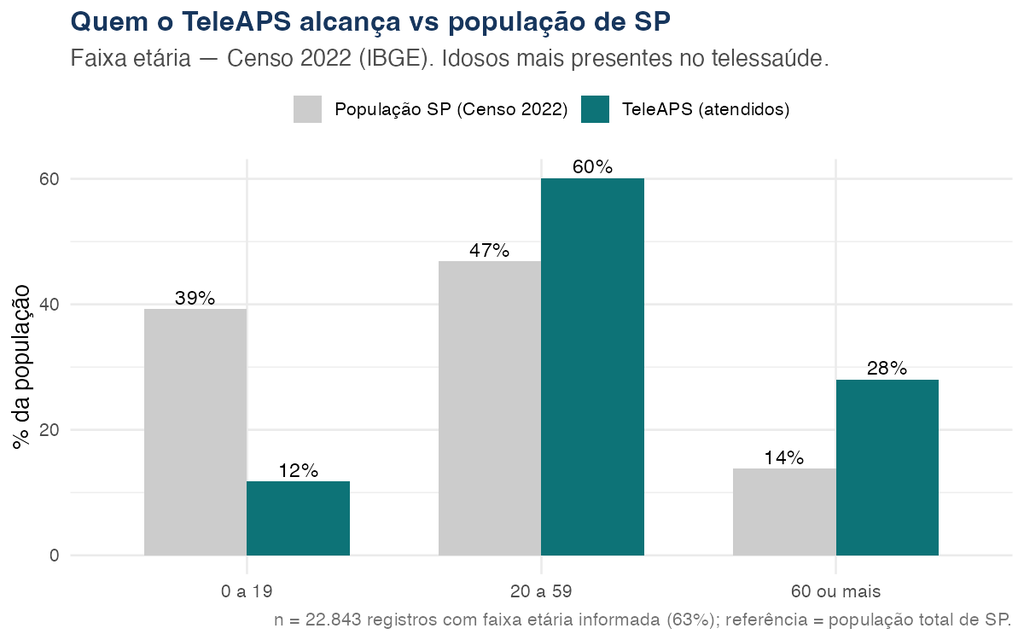

**Achado:** idosos (60+) **bem mais presentes** que na população — **28% vs 14%** (entre os 63% com faixa informada). População prioritária para condições crônicas.

## Desfecho — onde o cuidado acontece

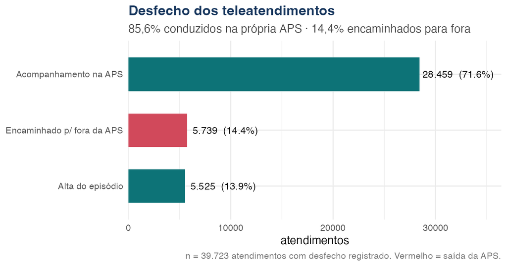

Dos **39.723** atendimentos com desfecho:

- **13,9%** alta do episódio
- **71,6%** acompanhamento na APS
- **14,4%** encaminhados para fora

**85,6% conduzidos na própria APS** — telessaúde evitando a saída do nível primário.

## Para onde a APS encaminha

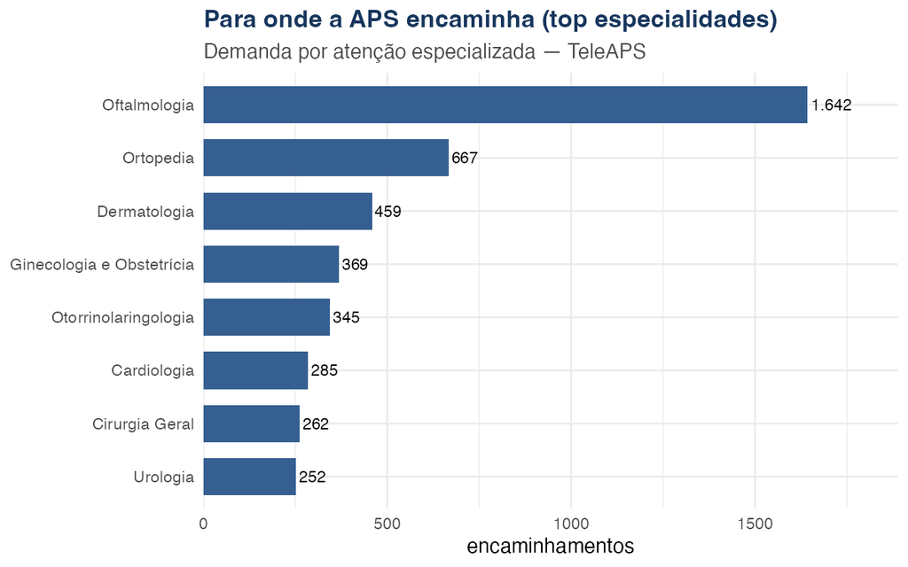

**Oftalmologia** lidera a demanda por atenção especializada (T3) — sinal útil para o planejamento da rede.

## Linkage territorial — prova de método

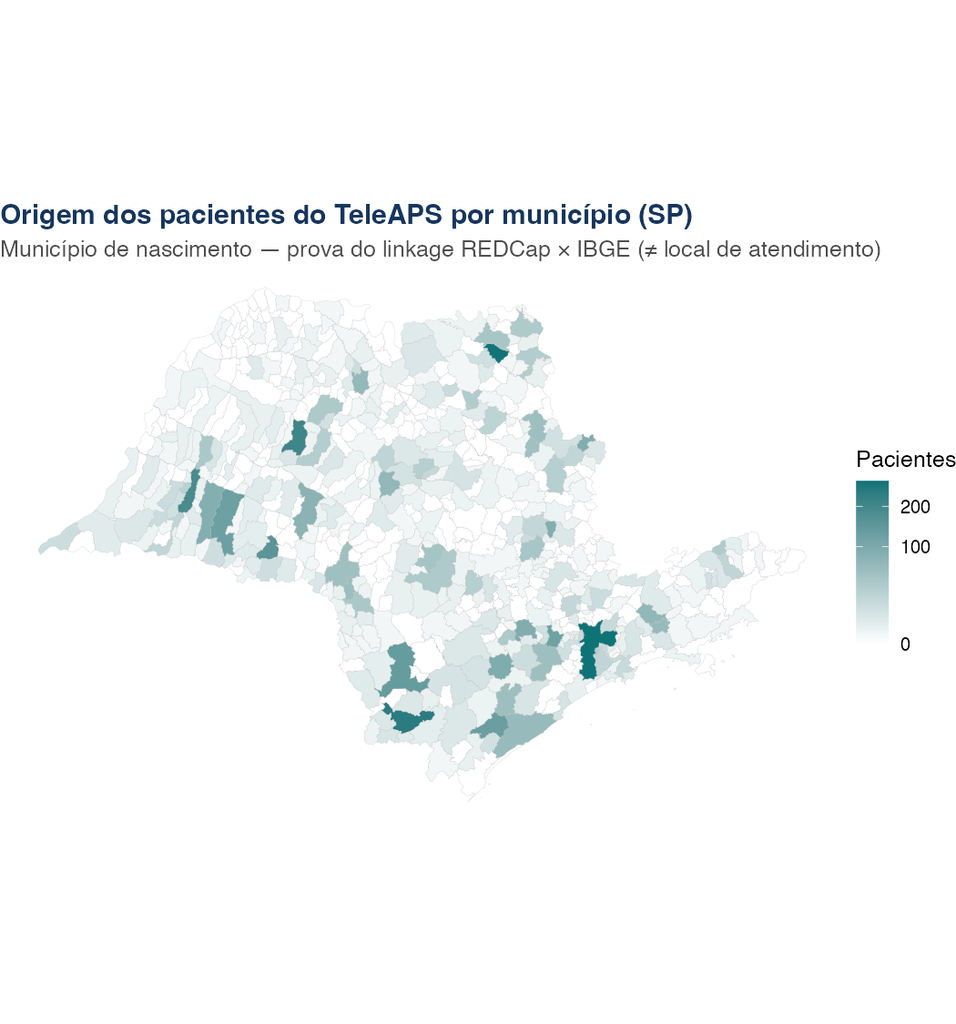

Cruzamento **REDCap × IBGE × geobr** funcionando: registros → município → mapa.

**Honestidade metodológica:** é *município de nascimento* (só 28% nasceram em SP), **não** o local de atendimento. O mapa prova o método; o território real virá do **de-para UBS→CNES** (em curso, com recursos próprios) + confirmação da semântica da unidade.

## O que temos × o que falta

| Capacidade | Temos hoje | Falta para avançar |
| --- | --- | --- |
| Bases públicas IBGE/CNES | ✅ tratadas | — |
| Bases INOVA (POC) | ✅ 3 iniciativas | bases **completas** |
| Linkage territorial | ✅ por município · unidade no formulário | confirmar semântica da UBS |
| Linkage de rede (CNES) | ✅ de-para UBS→CNES **em curso** (recursos próprios) | aplicar e curar as **70 UBS** |
| Interpretação dos campos | ⚠️ parcial | **dicionário atualizado** |

## O que pedimos — e por quê

| Precisamos de | Para quê | Status |
| --- | --- | --- |
| **Validar a unidade de atendimento** | a UBS já está no formulário (100% · 70 unidades) — falta confirmar a semântica | ◐ quase lá |
| **Dicionário de dados atualizado** | interpretar corretamente os 570+ campos e definir o escopo dos módulos ausentes | ○ falta |
| **Bases REDCap completas** | hoje é POC (amostra 2024–25) | ○ falta |

> **A unidade já está registrada** (100% · 70 UBS) e o **CNES resolvemos com recursos próprios** — a análise por unidade já está destravada. Faltam: **dicionário** e **bases completas**.

## Decisão conjunta — próximos passos

**A pergunta que orienta tudo:** o que a SES-SP precisa ver para decidir a **expansão**?

| Decisão | Opções |
| --- | --- |
| **Profundidade** | agregado (já temos) **vs** por **unidade** (temos a UBS e o CNES resolvemos internamente) — mostra *onde* expandir |
| **Escopo** | manter **3 iniciativas** **vs** incluir outras — o REDCap tem **7** (+AVC, PAD, UTI) |
| **Timing** | quando chegam as **bases completas** (define a entrega definitiva) |

**Recomendação (tática):** ir **por unidade** — maior valor para decidir *onde* investir — já iniciado com recursos próprios, sem esperar todas as iniciativas.

## Próximos passos

**Em curso agora (C4 · jul) — avanço com recursos próprios:**

- **Taxa por 100 mil hab.** agregada SP (≥18, padronizada por idade/sexo — Estimativas IBGE/TCU): converte o achado “28% vs 14%” em indicador comparável
- **De-para UBS→CNES** das 70 unidades → análise **por unidade** e território real de atendimento
- **Encaminhamentos por idade** (oftalmologia × idosos): subsídio para planejamento da rede

*Análises de aprofundamento não previstas no plano original — refletidas no cronograma do ciclo.*

**Sequência do cronograma:**

- **C4 (jul):** conclui TeleAPS (T2 população · T3 encaminhamentos)
- **C5–C7:** TeleSAP (S1–S6) · **C8–C11:** AME+Digital (A1–A4)
- **C12–C14:** Relatório Executivo para a SES-SP

**Postura:** ciclos quinzenais · versionamento e dicionário desde já · CIAP e CID-10 tratados separadamente.

### Obrigado

Bragatte, M.A.S · Bolsa PDI 2026 · TO 212.435

*com o que temos, já entregamos — e sabemos exatamente o que falta*